# HDAT9600 Generalised Linear Models Assignment

Submission deadline is 23:59 AEST Monday 27 July 2020

Murray Keogh

29/7/2020

## Instructions

This file is the R Markdown document in which you need to complete your HDAT9600 Generalised Linear Model assignment. This assignment is assessed and will count for 25% of the total course marks.

You should now complete the tasks described below, in the spaces provided. Don’t hesitate to ask the course convenor for help (use the OpenLearning environment to do that) — but remember that these are **individual** assignments and thus what you submit should be your own work, and you need to both understand and be able to explain what you did in your solutions. The course convenor is happy to point you in the right direction and to make suggestions, but won’t, of course, complete your assignment for you!

Each task below attracts the indicated number of marks (out of a total of 20 marks for the assignment).

## Task 1 (5 marks)

The data set labour.csv is from a 1977 survey of Canadian couples and families. The variables are work, whether the female of the household undertook paid employment either full time or part time (1=did not take paid employment, 0=took paid employment), hincome, income of the male member of the household (in $1000’s), children, a factor variable deﬁning whether children were present in the household and region, a factor with levels: Atlantic, Atlantic Canada; BC, British Columbia; Ontario; Prairie, Prairie provinces; Quebec.

The objective is to understand the inﬂuences on female participation in the labour force.

Build a suitable model (including, if appropriate, two-way interactions). Procure the RoC and AUC for any model you propose.

```r
# load the labour dataset and make it available for code in
# subsequent code chunks.

# read in data
lab <- read.csv('labour.csv',header=TRUE)

#examine the dataset
summary(lab)
```

```
##       work           hincome        children            region
##  Min.   :0.0000   Min.   : 1.00   Length:263         Length:263
##  1st Qu.:0.0000   1st Qu.:10.00   Class :character   Class :character
##  Median :1.0000   Median :14.00   Mode  :character   Mode  :character
##  Mean   :0.5894   Mean   :14.76
##  3rd Qu.:1.0000   3rd Qu.:19.00
##  Max.   :1.0000   Max.   :45.00
```

```r
head(lab)
```

```
##   work hincome children  region
## 1    1      15  present Ontario
## 2    1      13  present Ontario
## 3    1      45  present Ontario
## 4    1      23  present Ontario
## 5    1      19  present Ontario
## 6    1       7  present Ontario
```

```r
# insert your R code (with comment lines if you wish) here

#start by fitting simple logistic regression model with all predictors and possible interactions

lab_mod <- glm(work ~ hincome + children + region + hincome*children + hincome*region + children*region, family = binomial, data=lab)

#print the model summary

summary(lab_mod)
```

```
##
## Call:
## glm(formula = work ~ hincome + children + region + hincome *
##     children + hincome * region + children * region, family = binomial,
##     data = lab)
##
## Deviance Residuals:
##     Min       1Q   Median       3Q      Max
## -1.7712  -0.9884   0.7438   0.8109   1.8051
##
## Coefficients:
##                                Estimate Std. Error z value Pr(>|z|)
## (Intercept)                    -2.85076    1.58221  -1.802   0.0716 .
## hincome                         0.13331    0.07604   1.753   0.0796 .
## childrenpresent                 3.00271    1.42278   2.110   0.0348 *
## regionBC                        1.71562    1.84842   0.928   0.3533
## regionOntario                   0.83642    1.59203   0.525   0.5993
## regionPrairie                 -21.01374  751.91902  -0.028   0.9777
## regionQuebec                    1.23170    1.66433   0.740   0.4593
## hincome:childrenpresent        -0.06719    0.04606  -1.459   0.1446
## hincome:regionBC               -0.07725    0.09084  -0.850   0.3951
## hincome:regionOntario          -0.06625    0.06898  -0.960   0.3369
## hincome:regionPrairie           0.28320    0.17416   1.626   0.1039
## hincome:regionQuebec           -0.03479    0.08108  -0.429   0.6679
## childrenpresent:regionBC       -1.56025    1.48402  -1.051   0.2931
## childrenpresent:regionOntario  -0.04170    1.37135  -0.030   0.9757
## childrenpresent:regionPrairie  17.25444  751.91191   0.023   0.9817
## childrenpresent:regionQuebec   -0.76919    1.39747  -0.550   0.5820
## ---
## Signif. codes:  0 '***' 0.001 '**' 0.01 '*' 0.05 '.' 0.1 ' ' 1
##
## (Dispersion parameter for binomial family taken to be 1)
##
##     Null deviance: 356.15  on 262  degrees of freedom
## Residual deviance: 302.95  on 247  degrees of freedom
## AIC: 334.95
##
## Number of Fisher Scoring iterations: 15
```

```r
# search the model space for a reduced model using the step() function
lab_mod_reduced <- step(lab_mod, trace=1)
```

```
## Start:  AIC=334.95
## work ~ hincome + children + region + hincome * children + hincome *
##     region + children * region
##
##                    Df Deviance    AIC
## - hincome:region    4   310.67 334.67
## <none>                  302.95 334.95
## - hincome:children  1   305.10 335.10
## - children:region   4   311.90 335.90
##
## Step:  AIC=334.67
## work ~ hincome + children + region + hincome:children + children:region
##
##                    Df Deviance    AIC
## - children:region   4   316.54 332.54
## - hincome:children  1   311.51 333.51
## <none>                  310.67 334.67
##
## Step:  AIC=332.54
## work ~ hincome + children + region + hincome:children
##
##                    Df Deviance    AIC
## - region            4   319.12 327.12
## - hincome:children  1   317.30 331.30
## <none>                  316.54 332.54
##
## Step:  AIC=327.12
## work ~ hincome + children + hincome:children
##
##                    Df Deviance    AIC
## - hincome:children  1   319.73 325.73
## <none>                  319.12 327.12
##
## Step:  AIC=325.73
## work ~ hincome + children
##
##            Df Deviance    AIC
## <none>          319.73 325.73
## - hincome   1   324.56 328.56
## - children  1   351.06 355.06
```

```r
summary(lab_mod_reduced)
```

```
##
## Call:
## glm(formula = work ~ hincome + children, family = binomial, data = lab)
##
## Deviance Residuals:
##     Min       1Q   Median       3Q      Max
## -1.9970  -0.9292   0.7768   0.8652   1.6767
##
## Coefficients:
##                 Estimate Std. Error z value Pr(>|z|)
## (Intercept)     -1.33583    0.38376  -3.481   0.0005 ***
## hincome          0.04231    0.01978   2.139   0.0324 *
## childrenpresent  1.57565    0.29226   5.391    7e-08 ***
## ---
## Signif. codes:  0 '***' 0.001 '**' 0.01 '*' 0.05 '.' 0.1 ' ' 1
##
## (Dispersion parameter for binomial family taken to be 1)
##
##     Null deviance: 356.15  on 262  degrees of freedom
## Residual deviance: 319.73  on 260  degrees of freedom
## AIC: 325.73
##
## Number of Fisher Scoring iterations: 4
```

```r
#region variable and all interaction variables are dropped

#check region variable on it's own to assess any significance

drop1(glm(work ~ region, family = binomial, data=lab), test="Chi")
```

```
## Single term deletions
##
## Model:
## work ~ region
##        Df Deviance    AIC    LRT Pr(>Chi)
## <none>      353.65 363.65
## region  4   356.15 358.15 2.4968   0.6452
```

```r
#region not significant

#confidence intervals for parameters hincome and children

confint(lab_mod_reduced)
```

```
##                        2.5 %      97.5 %
## (Intercept)     -2.115336975 -0.60590835
## hincome          0.004471769  0.08225743
## childrenpresent  1.012720928  2.16143847
```

```r
#attain the AOC and RUC for the lab_mod_reduced model using only hincome and children

#omit missing values
lab_df <- na.omit(lab)
#change work to yes or no
lab_df$work_cat <- ifelse(lab_df$work==1, "yes", "no")
#change work to factor
lab_df$work_cat <- as.factor(lab_df$work_cat)
#append probability and predicted values to dataframe
lab_df %>% mutate(predprob=predict(lab_mod_reduced, type="response")) %>%
            mutate(pred_outcome=as.factor(ifelse(predprob < 0.5, "no", "yes"))) -> lab_df

#calculate the confusion matrix

confusionMatrix(lab_df$pred_outcome, lab_df$work_cat, positive = "yes")
```

```
## Confusion Matrix and Statistics
##
##           Reference
## Prediction  no yes
##        no   53  23
##        yes  55 132
##
##                Accuracy : 0.7034
##                  95% CI : (0.6442, 0.758)
##     No Information Rate : 0.5894
##     P-Value [Acc > NIR] : 8.383e-05
##
##                   Kappa : 0.3585
##
##  Mcnemar's Test P-Value : 0.000448
##
##             Sensitivity : 0.8516
##             Specificity : 0.4907
##          Pos Pred Value : 0.7059
##          Neg Pred Value : 0.6974
##              Prevalence : 0.5894
##          Detection Rate : 0.5019
##    Detection Prevalence : 0.7110
##       Balanced Accuracy : 0.6712
##
##        'Positive' Class : yes
##
```

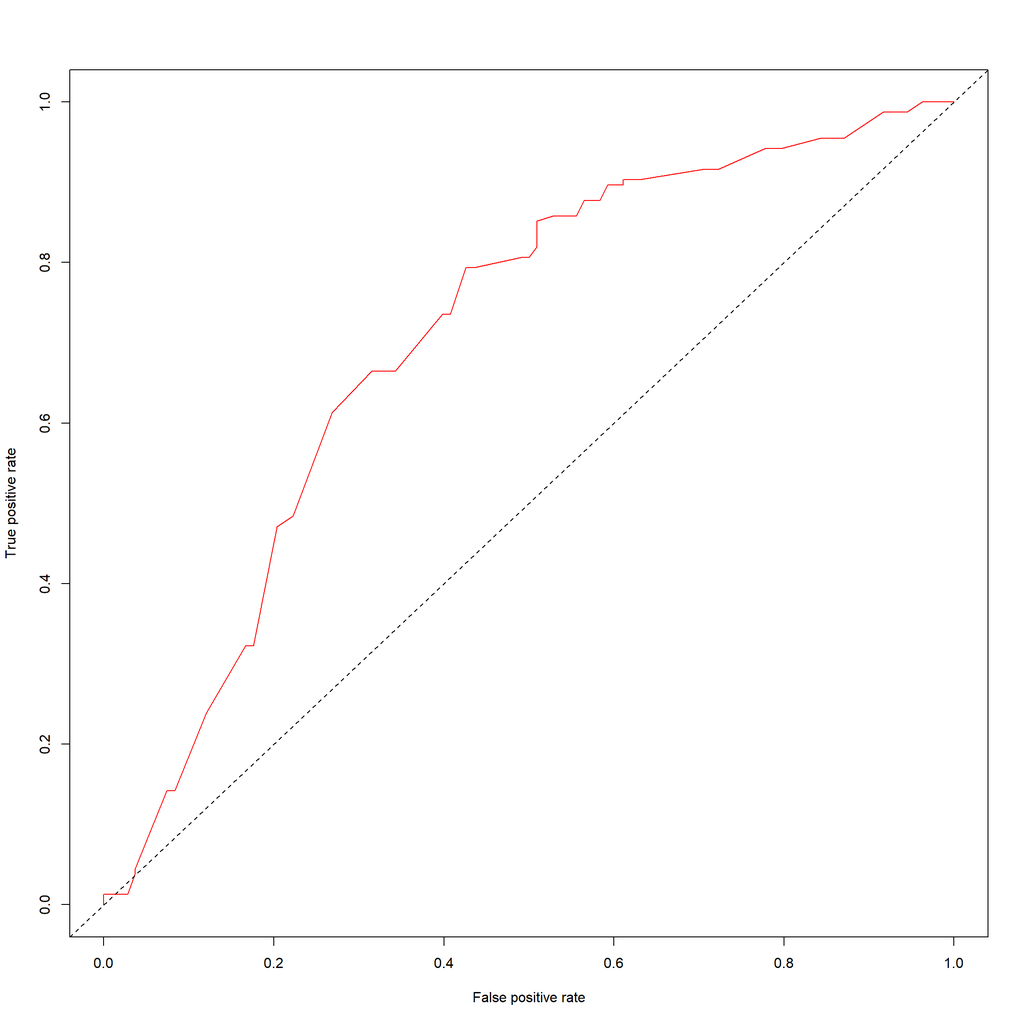

```r
#plot the ROC using the ROCR package

pred <- prediction(lab_df$predprob, lab_df$work_cat)
perf <- performance(pred, measure = "tpr", x.measure = "fpr")
plot(perf, col=rainbow(10))
abline(0,1, lty=2)
```

```r
#calculate the AUC using the ROCR package

auc <- performance(pred,measure="auc")
auc <- auc@y.values[[1]]
auc
```

```
## [1] 0.7054659
```

From the above model summary, a female undertaking work was influenced significantly by whether the household had children and the husband’s income. The region in which the household is located was not significant, and no interaction effects between the three predictor variables were found significant.

## Task 2 (3 marks)

In this task, you will be using the `retinopathy` dataset which comes with the *catdata* package for R. You will need to install that package using the Packages tab in RStudio or the `install.packages()` function at R console prompt.

The data has three outcome levels: RET=0: no retinopathy, RET=1 nonproliferative retinopathy, RET=2 advanced retinopathy or blind. For the purposes of this exercise, combine 1 and 2 into 1.

Ensure that the smoking variable is a factor with appropriately ordered levels.

Now fit a series of logistic regression models to the data. The first model should use `RET` as the outcome and the other four variables as predictors. Then fit additional models, each with a single pair-wise interaction term added — so the first additional model would have the four predictors plus an interaction terms between `SM` and `DIAB`, the next model would have the four predictors plus an interaction terms between `SM` and `GH`, and so on. Make sure you have fitted models with all possible pair-wise interaction terms. Thus, each additional model should have the four predictors plus a single interaction term.

Determine if the interaction term in any of the additional models is significant. Compare the goodness-of-fit of this model with the goodness-of-fit of the original model with no interaction terms, using the AIC and one of the several available pseudo-R-squared statistics. Comment on whether the model with the interaction term is preferable, if the goal is explanation, rather than prediction.

```r
#load data and examine the datset
data('retinopathy',package='catdata')
head(retinopathy)
```

```
##   RET SM  DIAB        GH    BP
## 1   0  1  7.04  8.472001 91.60
## 2   2  1 16.31 11.276756 77.75
## 3   2  0 24.46  7.910171 95.80
## 4   0  1  6.57  7.065646 74.20
## 5   2  1 27.94  9.970089 79.50
## 6   1  1 22.21  6.752969 78.40
```

```r
summary(retinopathy)
```

```
##       RET               SM              DIAB             GH
##  Min.   :0.0000   Min.   :0.0000   Min.   : 4.50   Min.   : 4.958
##  1st Qu.:0.0000   1st Qu.:0.0000   1st Qu.: 8.60   1st Qu.: 6.843
##  Median :0.0000   Median :1.0000   Median :13.57   Median : 7.660
##  Mean   :0.5416   Mean   :0.5302   Mean   :15.00   Mean   : 7.782
##  3rd Qu.:1.0000   3rd Qu.:1.0000   3rd Qu.:20.27   3rd Qu.: 8.467
##  Max.   :2.0000   Max.   :1.0000   Max.   :38.38   Max.   :12.904
##        BP
##  Min.   : 58.60
##  1st Qu.: 75.00
##  Median : 79.80
##  Mean   : 80.05
##  3rd Qu.: 84.20
##  Max.   :104.00
```

```r
#check smoking variable
class(retinopathy$SM)
```

```
## [1] "integer"
```

```r
#change smoking variable to ordered factor
retinopathy$SM <- factor(retinopathy$SM, ordered = TRUE,levels = c(0, 1))
class(retinopathy$SM)
```

```
## [1] "ordered" "factor"
```

```r
levels(retinopathy$SM)
```

```
## [1] "0" "1"
```

```r
#combine RET 1,2 into 1
#check frequency of each

retinopathy %>% group_by(RET) %>% summarise(n())
```

```
## # A tibble: 3 x 2
##     RET `n()`
##   <int> <int>
## 1     0   388
## 2     1   118
## 3     2   107
```

```r
retinopathy$RET <- ifelse(retinopathy$RET == 2,1,retinopathy$RET)

retinopathy %>% group_by(RET) %>% summarise(n())
```

```
## # A tibble: 2 x 2
##     RET `n()`
##   <dbl> <int>
## 1     0   388
## 2     1   225
```

```r
#fit logistic regressions for all variables and then each with a single pair-wise interaction term

ret_mod_1 <- glm(RET ~ SM + DIAB + GH + BP, family = binomial, data=retinopathy)

ret_mod_2 <- glm(RET ~ SM + DIAB + GH + BP + SM*DIAB, family = binomial, data=retinopathy)

ret_mod_3 <- glm(RET ~ SM + DIAB + GH + BP + SM*GH, family = binomial, data=retinopathy)

ret_mod_4 <- glm(RET ~ SM + DIAB + GH + BP + SM*BP, family = binomial, data=retinopathy)

ret_mod_5 <- glm(RET ~ SM + DIAB + GH + BP + DIAB*GH, family = binomial, data=retinopathy)

ret_mod_6 <- glm(RET ~ SM + DIAB + GH + BP + DIAB*BP, family = binomial, data=retinopathy)

ret_mod_7 <- glm(RET ~ SM + DIAB + GH + BP + GH*BP, family = binomial, data=retinopathy)

#determine if interaction term in any of the models is significant
#only interaction term significant at the 95% level is DIAB*BP

summary(ret_mod_6)
```

```
##
## Call:
## glm(formula = RET ~ SM + DIAB + GH + BP + DIAB * BP, family = binomial,
##     data = retinopathy)
##
## Deviance Residuals:
##     Min       1Q   Median       3Q      Max
## -2.1640  -0.7862  -0.4739   0.8725   2.3207
##
## Coefficients:
##              Estimate Std. Error z value Pr(>|z|)
## (Intercept) -5.814031   2.962064  -1.963   0.0497 *
## SM.L         0.286672   0.147338   1.946   0.0517 .
## DIAB        -0.210492   0.160427  -1.312   0.1895
## GH           0.434498   0.080683   5.385 7.24e-08 ***
## BP          -0.003608   0.036632  -0.098   0.9215
## DIAB:BP      0.004268   0.002021   2.112   0.0347 *
## ---
## Signif. codes:  0 '***' 0.001 '**' 0.01 '*' 0.05 '.' 0.1 ' ' 1
##
## (Dispersion parameter for binomial family taken to be 1)
##
##     Null deviance: 805.93  on 612  degrees of freedom
## Residual deviance: 626.37  on 607  degrees of freedom
## AIC: 638.37
##
## Number of Fisher Scoring iterations: 4
```

```r
#compare the goodness of fit of this model with original model

summary(ret_mod_1)
```

```
##
## Call:
## glm(formula = RET ~ SM + DIAB + GH + BP, family = binomial, data = retinopathy)
##
## Deviance Residuals:
##     Min       1Q   Median       3Q      Max
## -2.0469  -0.8017  -0.4595   0.8864   2.3998
##
## Coefficients:
##              Estimate Std. Error z value Pr(>|z|)
## (Intercept) -11.48511    1.39176  -8.252  < 2e-16 ***
## SM.L          0.27542    0.14626   1.883   0.0597 .
## DIAB          0.12925    0.01464   8.827  < 2e-16 ***
## GH            0.43283    0.08072   5.362 8.23e-08 ***
## BP            0.06802    0.01484   4.582 4.60e-06 ***
## ---
## Signif. codes:  0 '***' 0.001 '**' 0.01 '*' 0.05 '.' 0.1 ' ' 1
##
## (Dispersion parameter for binomial family taken to be 1)
##
##     Null deviance: 805.93  on 612  degrees of freedom
## Residual deviance: 630.94  on 608  degrees of freedom
## AIC: 640.94
##
## Number of Fisher Scoring iterations: 4
```

```r
# disable printing in scientific format
options(scipen=999)

#show AIC and McFadden pseudo-R-squared statistics
test = c("AIC","McFadden")

PseudoR2(ret_mod_1, which = test)
```

```
##         AIC    McFadden
## 640.9361439   0.2171329
```

```r
PseudoR2(ret_mod_6, which = test)
```

```
##         AIC    McFadden
## 638.3747273   0.2227927
```

I found that the interaction variable, DIAB*BP, was significant at the 95% significance level. The model that incorporated this variable had an AIC and MCFadden Pseudo-R-Squared statistic of 638.37 and .222. Both statistics were favorable when compared to the original model incorporating no interaction terms that had an AIC of 640.94 and McFadden Pseudo-R-Squared of .217. However, if the goal of this analysis is explanation, I would recommend using the simpler model because of the ease of explanation of the predictor variables.

## Task 3 (6 marks)

In this task, you will be using the `esoph` dataset which comes with the core R installation.

The manual (help) page for the `esoph` dataset states the following:

**Description** > Data from a case-control study of (o)esophageal cancer in Ille-et-Vilaine, France. > A data frame with records for 88 age/alcohol/tobacco combinations.

**Columns**

**`agegp`**

Age group: 25–34 years, 35–44 years, 45–54 years, 55–64 years, 65–74 years, 75+ years

**`alcgp`**

Alcohol consumption: 0–39 gm/day, 40–79 gm/day, 80–119 gm/day, 120+ gm/day

**`tobgp`**

Tobacco consumption: 0– 9 gm/day, 10–19 gm/day, 20–29 gm/day, 30+ gm/day

**`ncases`**

Number of cases

**`ncontrols`**

Number of controls

### Task 3.a (2 marks)

Carry out a brief graphical exploratory data analysis: create a separate scatterplot for each of the predictor variables, using the predictor variable for the x-axis and the proportion of cases as the y-axis. Layer/facet each of these plots by the two other predictor variables (the ones not used for the x-axis) to form a grid of sub-plots. If necessary, rotate or adjust the axis labels and/or use the fig.width and fig.height parameters for the R code blocks below to ensure that the resulting plot is legible. Place code for each plot in a separate code block. Write a brief commentary on the data (one or two sentences only).

```r
#load data and examine the datset
data(esoph)

#examine the dataset
head(esoph)
```

```
##   agegp     alcgp    tobgp ncases ncontrols
## 1 25-34 0-39g/day 0-9g/day      0        40
## 2 25-34 0-39g/day    10-19      0        10
## 3 25-34 0-39g/day    20-29      0         6
## 4 25-34 0-39g/day      30+      0         5
## 5 25-34     40-79 0-9g/day      0        27
## 6 25-34     40-79    10-19      0         7
```

```r
summary(esoph)
```

```
##    agegp          alcgp         tobgp        ncases         ncontrols
##  25-34:15   0-39g/day:23   0-9g/day:24   Min.   : 0.000   Min.   : 1.00
##  35-44:15   40-79    :23   10-19   :24   1st Qu.: 0.000   1st Qu.: 3.00
##  45-54:16   80-119   :21   20-29   :20   Median : 1.000   Median : 6.00
##  55-64:16   120+     :21   30+     :20   Mean   : 2.273   Mean   :11.08
##  65-74:15                                3rd Qu.: 4.000   3rd Qu.:14.00
##  75+  :11                                Max.   :17.000   Max.   :60.00
```

```r
#create column prop_cases

esoph$prop_cases = esoph$ncases / sum(esoph$ncases)
```

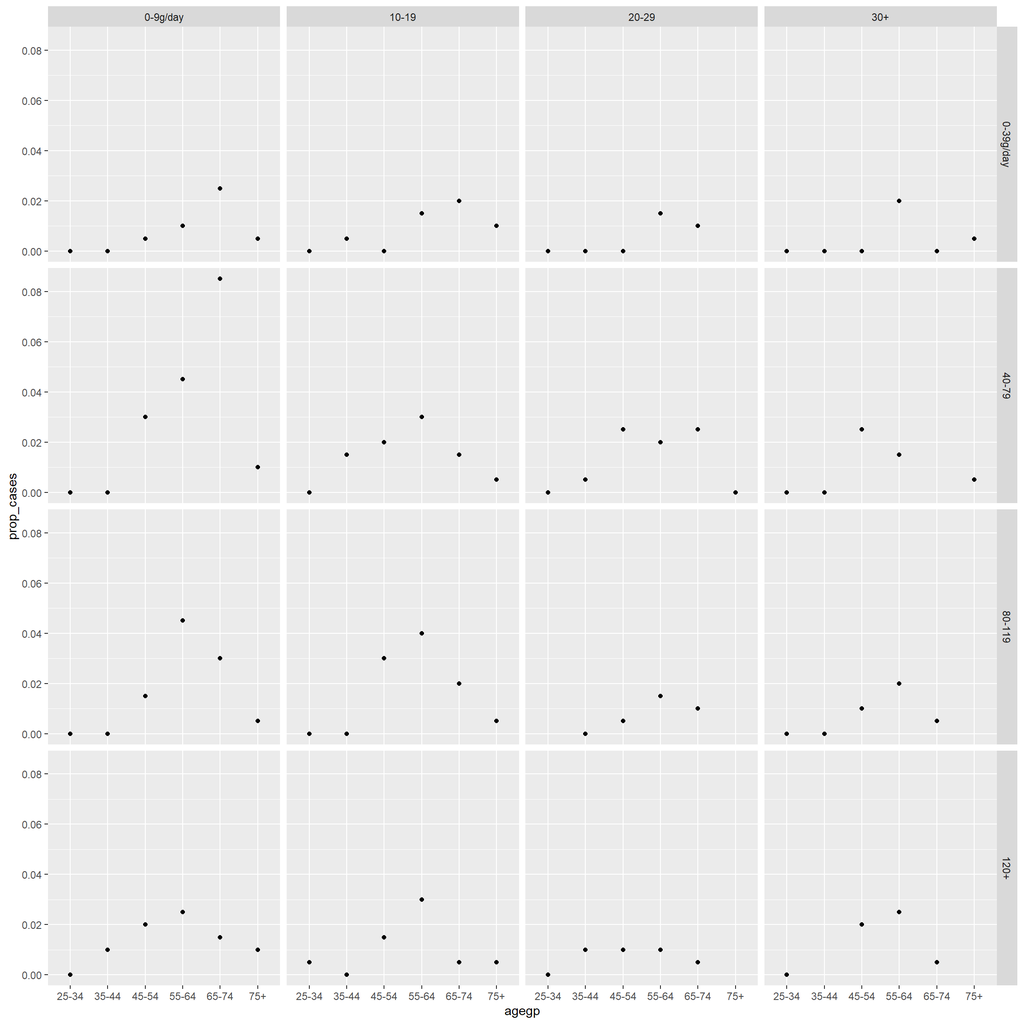

```r
#create the plot for agpgp

agegp_plot <- ggplot(esoph, aes(agegp, prop_cases)) + geom_point()
agegp_plot + facet_grid(vars(alcgp), vars(tobgp))
```

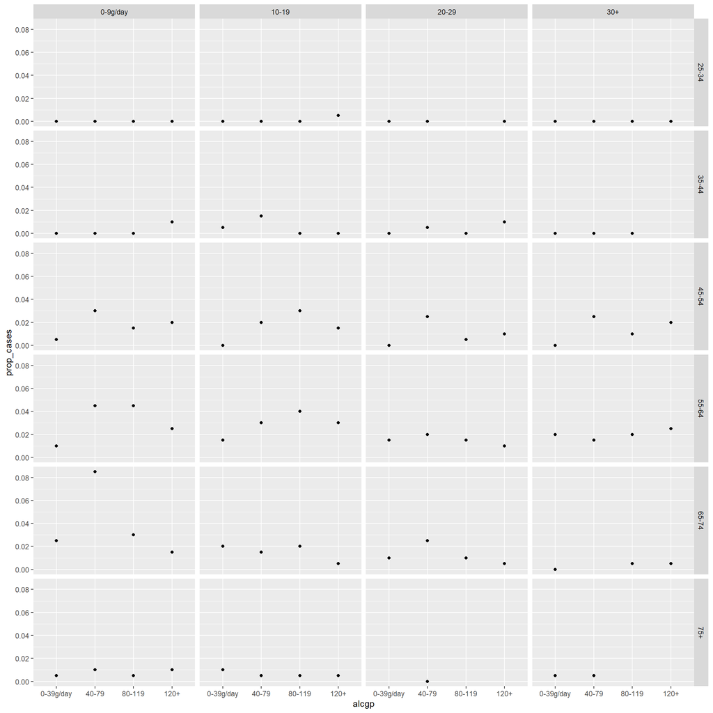

```r
#create the plot for alcgp

alcgp_plot <- ggplot(esoph, aes(alcgp, prop_cases)) + geom_point()
alcgp_plot + facet_grid(vars(agegp), vars(tobgp))
```

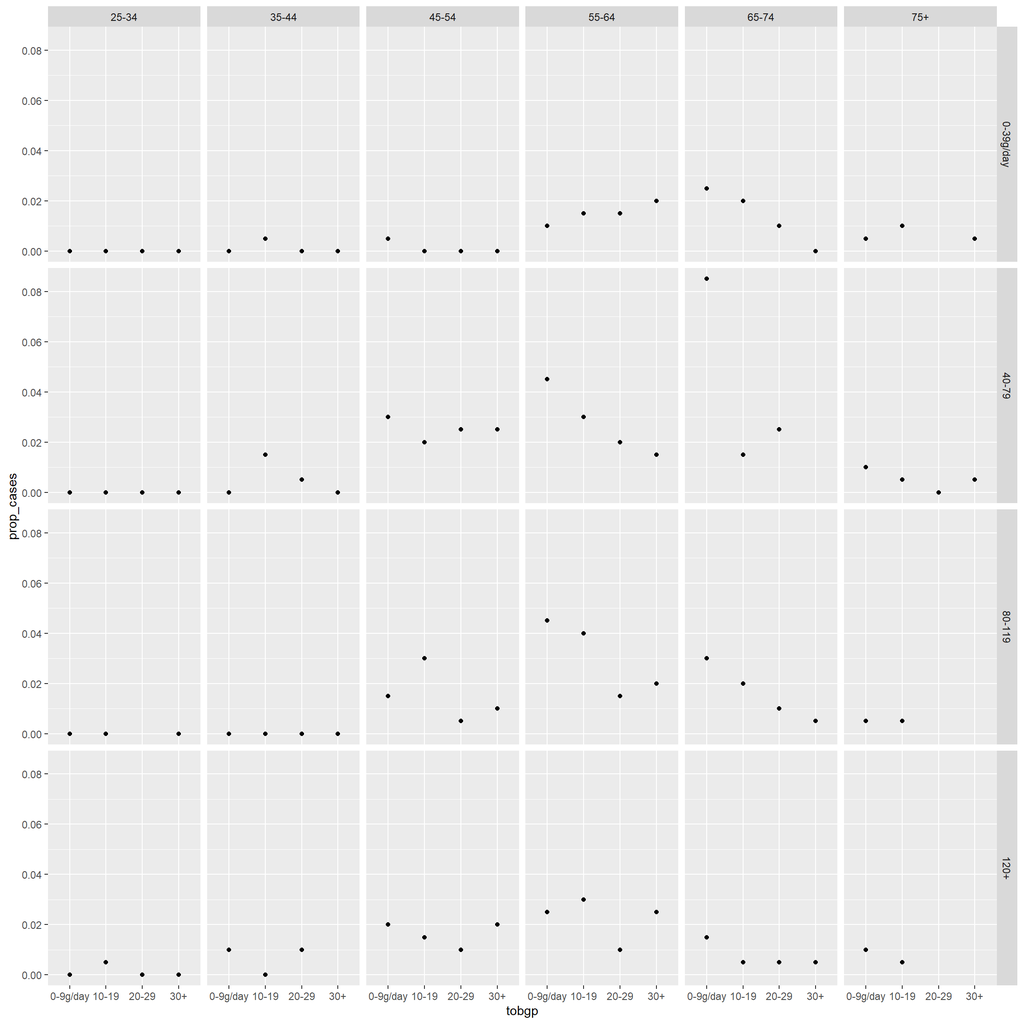

```r
#create the plot for tobgp

tobgp_plot <- ggplot(esoph, aes(tobgp, prop_cases)) + geom_point()
tobgp_plot + facet_grid(vars(alcgp), vars(agegp))
```

From the above graphs, the most prominent feature I decipher is that the highest proportion of participants fall in the 45-74 age buckets. I also observe that within these age buckets, both tobacco and alcohol usage are close to uniformly distributed.

### 3.b (2 marks)

Examine the `class()` and/or the `str()` of the `agegp`, `alcgp` and `tobgp` variables in the `esoph` dataset. Fit a binomial GLM with `agegp`, `alcgp` and `tobgp` as the predictors (and `ncases` and `ncontrols` used for the outcome) and display the model object using `summary()`. Describe what you notice about the output. Do some research to discover why the model has been fitted by R in that way, and write a brief (one or two sentence) explanation.

```r
# insert your R code (with comment lines if you wish) here
#examine class of predictor variables
class(esoph$agegp)
```

```
## [1] "ordered" "factor"
```

```r
class(esoph$alcgp)
```

```
## [1] "ordered" "factor"
```

```r
class(esoph$tobgp)
```

```
## [1] "ordered" "factor"
```

```r
levels(esoph$agegp)
```

```
## [1] "25-34" "35-44" "45-54" "55-64" "65-74" "75+"
```

```r
levels(esoph$alcgp)
```

```
## [1] "0-39g/day" "40-79"     "80-119"    "120+"
```

```r
levels(esoph$tobgp)
```

```
## [1] "0-9g/day" "10-19"    "20-29"    "30+"
```

```r
#fit the model to ncases and ncontrols
esoph_mod <- glm(cbind(ncases, ncontrols) ~ agegp + alcgp + tobgp, family = binomial, data=esoph)
summary(esoph_mod)
```

```
##
## Call:
## glm(formula = cbind(ncases, ncontrols) ~ agegp + alcgp + tobgp,
##     family = binomial, data = esoph)
##
## Deviance Residuals:
##     Min       1Q   Median       3Q      Max
## -1.6891  -0.5618  -0.2168   0.2314   2.0642
##
## Coefficients:
##             Estimate Std. Error z value             Pr(>|z|)
## (Intercept) -1.77997    0.19796  -8.992 < 0.0000000000000002 ***
## agegp.L      3.00534    0.65215   4.608   0.0000040587891154 ***
## agegp.Q     -1.33787    0.59111  -2.263              0.02362 *
## agegp.C      0.15307    0.44854   0.341              0.73291
## agegp^4      0.06410    0.30881   0.208              0.83556
## agegp^5     -0.19363    0.19537  -0.991              0.32164
## alcgp.L      1.49185    0.19935   7.484   0.0000000000000723 ***
## alcgp.Q     -0.22663    0.17952  -1.262              0.20680
## alcgp.C      0.25463    0.15906   1.601              0.10942
## tobgp.L      0.59448    0.19422   3.061              0.00221 **
## tobgp.Q      0.06537    0.18811   0.347              0.72823
## tobgp.C      0.15679    0.18658   0.840              0.40071
## ---
## Signif. codes:  0 '***' 0.001 '**' 0.01 '*' 0.05 '.' 0.1 ' ' 1
##
## (Dispersion parameter for binomial family taken to be 1)
##
##     Null deviance: 227.241  on 87  degrees of freedom
## Residual deviance:  53.973  on 76  degrees of freedom
## AIC: 225.45
##
## Number of Fisher Scoring iterations: 6
```

### 3.c (2 marks)

Use `unclass()` on each of the three predictor variables in task 3.b above to convert them to numeric variables and re-fit the model. Can the model be simplified? Justify your response? (2 marks)

```r
# insert your R code (with comment lines if you wish) here
#unclass each of the predictor variables
esoph$agegp <- unclass(esoph$agegp)
esoph$alcgp <- unclass(esoph$alcgp)
esoph$tobgp <- unclass(esoph$tobgp)

#all are integer
class(esoph$agegp)
```

```
## [1] "integer"
```

```r
class(esoph$alcgp)
```

```
## [1] "integer"
```

```r
class(esoph$tobgp)
```

```
## [1] "integer"
```

```r
#fit the model to ncases and ncontrols
esoph_mod_2 <- glm(cbind(ncases, ncontrols) ~ agegp + alcgp + tobgp, family = binomial, data=esoph)
summary(esoph_mod_2)
```

```
##
## Call:
## glm(formula = cbind(ncases, ncontrols) ~ agegp + alcgp + tobgp,
##     family = binomial, data = esoph)
##
## Deviance Residuals:
##     Min       1Q   Median       3Q      Max
## -1.9586  -0.8555  -0.4358   0.3075   1.9349
##
## Coefficients:
##             Estimate Std. Error z value             Pr(>|z|)
## (Intercept) -5.59594    0.41540 -13.471 < 0.0000000000000002 ***
## agegp        0.52867    0.07188   7.355    0.000000000000191 ***
## alcgp        0.69382    0.08342   8.317 < 0.0000000000000002 ***
## tobgp        0.27446    0.08074   3.399             0.000676 ***
## ---
## Signif. codes:  0 '***' 0.001 '**' 0.01 '*' 0.05 '.' 0.1 ' ' 1
##
## (Dispersion parameter for binomial family taken to be 1)
##
##     Null deviance: 227.241  on 87  degrees of freedom
## Residual deviance:  73.959  on 84  degrees of freedom
## AIC: 229.44
##
## Number of Fisher Scoring iterations: 4
```

The simplified model above has an AIC of 229.44 and residual deviance of 73.959 compared to the AIC of 225.45 and residual deviance of 53.973 of the factor predictor model. Since the performance measures are close, I think the simplified model could be used in this scenario depending on what the final goal of using the model might be. If the goal is only prediction, the more complex model may yield better results. However, if the goal is explanation, the simpler model is the better solution.

## Task 4 (4 marks)

In this task, you will be using the `esdcomp` dataset which comes with the *faraway* package for R.

```r
#load the dataset
data(esdcomp, package="faraway")

#examine the dataset
head(esdcomp)
```

```
##   visits complaints residency gender revenue   hours
## 1   2014          2         Y      F  263.03 1287.25
## 2   3091          3         N      M  334.94 1588.00
## 3    879          1         Y      M  206.42  705.25
## 4   1780          1         N      M  226.32 1005.50
## 5   3646         11         N      M  288.91 1667.25
## 6   2690          1         N      M  275.94 1517.75
```

```r
summary(esdcomp)
```

```
##      visits       complaints     residency gender    revenue
##  Min.   : 879   Min.   : 0.000   N:24      F:12   Min.   :206.4
##  1st Qu.:2036   1st Qu.: 1.000   Y:20      M:32   1st Qu.:235.9
##  Median :2384   Median : 2.000                    Median :258.5
##  Mean   :2386   Mean   : 3.341                    Mean   :260.1
##  3rd Qu.:2813   3rd Qu.: 5.000                    3rd Qu.:282.3
##  Max.   :3763   Max.   :11.000                    Max.   :334.9
##      hours
##  Min.   : 589
##  1st Qu.:1207
##  Median :1512
##  Mean   :1417
##  3rd Qu.:1642
##  Max.   :1917
```

Read the manual page for the `esdcomp` dataset for background information.

Fit a binomial GLM to the `esdcomp` dataset using the number of complaints out of the number of visits as the outcome, and all the other variables as predictors. Are any of the predictors significant? How well does the model fit the data?

```r
#fit model for had_comp outcome variables
esdcomp_mod <- glm(cbind(complaints,visits) ~ gender+residency+revenue+hours,family='binomial',data=esdcomp)

#summary of model
summary(esdcomp_mod)
```

```
##
## Call:
## glm(formula = cbind(complaints, visits) ~ gender + residency +
##     revenue + hours, family = "binomial", data = esdcomp)
##
## Deviance Residuals:
##     Min       1Q   Median       3Q      Max
## -1.9422  -0.9484  -0.3130   0.7853   1.8020
##
## Coefficients:
##               Estimate Std. Error z value            Pr(>|z|)
## (Intercept) -8.1198302  0.8508567  -9.543 <0.0000000000000002 ***
## genderM      0.1954066  0.2182869   0.895              0.3707
## residencyY  -0.2089384  0.2013108  -1.038              0.2993
## revenue      0.0015755  0.0028320   0.556              0.5780
## hours        0.0007017  0.0003508   2.001              0.0454 *
## ---
## Signif. codes:  0 '***' 0.001 '**' 0.01 '*' 0.05 '.' 0.1 ' ' 1
##
## (Dispersion parameter for binomial family taken to be 1)
##
##     Null deviance: 63.348  on 43  degrees of freedom
## Residual deviance: 54.444  on 39  degrees of freedom
## AIC: 187.17
##
## Number of Fisher Scoring iterations: 5
```

```r
#hours is significant at 95% level.

#compute Pearson's residuals to assess model fit

#Pearson's Statistic
(pearsons_chisq <- sum(residuals(esdcomp_mod, type = "pearson")^2))
```

```
## [1] 53.32488
```

```r
#P-Value for test statistic with n - 4 - 1 degrees of freedom
1 - pchisq(pearsons_chisq, nrow(esdcomp) - 5)
```

```
## [1] 0.06289442
```

From above, hours is the only predictor variable that is significant (95% level). The model has an AIC of 187.17 and the residual deviance of 54.44 is lower than the null deviance indicating the model with predictors results in a better fit. I test this formally by calculating the Pearson’s Chi-Square Statistic and p-value, 53.32 and .06 respectively. The p-value of .06 is non-significant at the 95% level, and thus I fail to reject the null hypothesis that there is no lack-of-fit. This provides evidence that the model does fit the data reasonably well.

### Task 5 (2 marks)

Explain in your own words why logistic regression may be unsuitable to model common outcomes.

For logistic regression to work well, the outcomes must be separable due to differences in the predictor variables. Common outcomes cause issues because any deviance in the predictor variables still result in the common outcome. As a result, the model may work well (since confidence is high for common outcome to occur anyway) but the logistic regression does not lead to additional knowledge or predictive power.

## Save, knit and submit

**Reminder**: don’t forget to save this file, to knit it to check that everything works, and then submit via the drop box in Openlearning.

## Submit your assignment

When you have finished, and are satisfied with your assignment solutions, and this file knits without errors and the output looks the way you want, then you should submit via the drop box in Openlearning.

### Problems?

If you encounter problems with any part of the process described above, please contact the course convenor via OpenLearning as soon as possible so that the issues can be resolved in good time, and well before the assignment is due.